# Final Project

Alex Wang

12/17/2019

**Background**

- Prostate Cancer is the second most common cancer in males
- Many cases take years to progress to malignancy
- Active Surveillance (AS) is a well-accepted alternative to definitive therapy in patients with low-favorable intermediate prostate cancer (PCa)

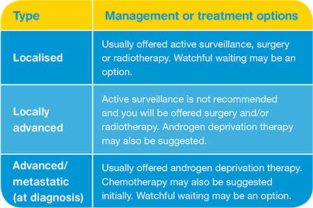

```r
knitr::include_graphics('./prostate_management.jpg')
```

**Methods**

- Institutional database of patients on AS from 11/2003-5/2019
- ≥ 2 mpMRIs, ≥ 2 prostate biopsies, and a diagnosis of prostate cancer

**Patient data**

- 480 patients on AS
- Prostate Imaging Reporting and Data System (PIRADS) score is a score from 1 to 5 and shown to be related to the probability of finding a diagnosis of prostate cancer on prostate biopsy
- First started being used at NIH in 2014

```r
library(tidyr)
library(dplyr)
```

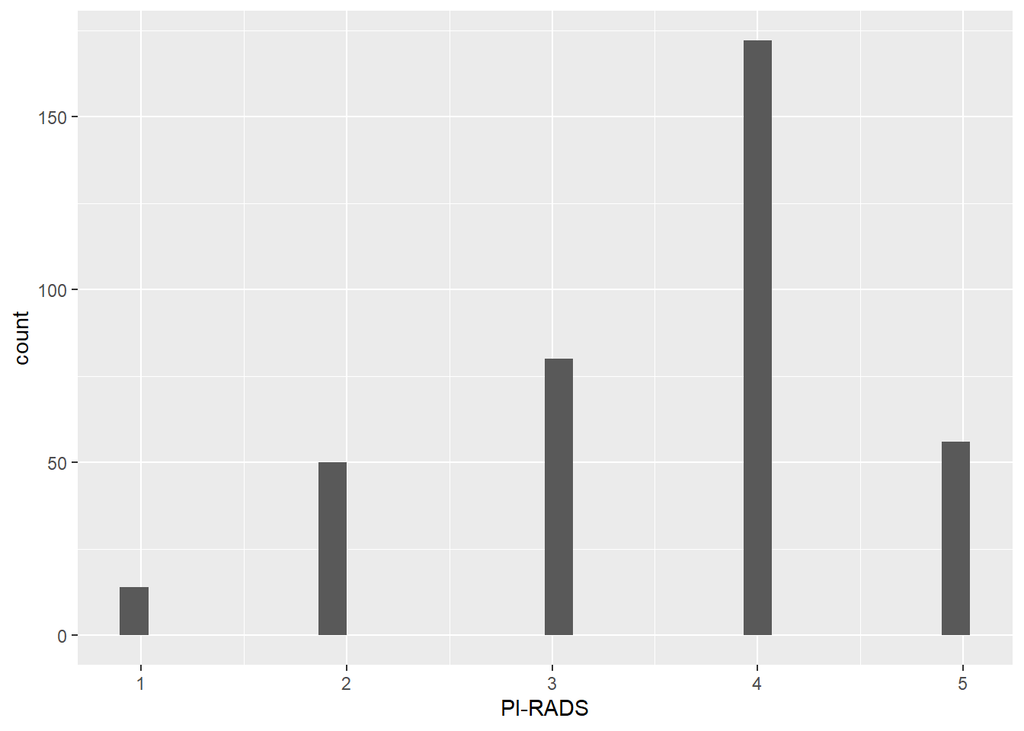

```r
library(rio)
library(survival)
library(ggplot2)
library(readxl)
patients <- read_excel("C:/Users/wangalz/OneDrive - National Institutes of Health/Databases/AS Manipulations/patients_tab.xlsx",
                       col_types = c("numeric", "text", "text",
                                     "text", "date", "text", "date", "numeric",
                                     "date", "date", "numeric", "numeric",
                                     "numeric", "text", "date", "text",
                                     "text", "text", "text", "numeric",
                                     "numeric"))
mri <- read_excel("C:/Users/wangalz/OneDrive - National Institutes of Health/Databases/R analyses/mri.xlsx",
                  col_types = c("numeric", "numeric", "numeric",
                                "numeric", "numeric", "numeric",
                                "numeric", "numeric", "numeric", "text",
                                "text", "text", "text", "text", "numeric",
                                "numeric", "text", "text", "text",
                                "text", "text", "text", "text", "text",
                                "text", "text", "text"))

#Finding first MRI with PI-RADs information

mri_pirads <- subset(mri, `PI-RADS` != "NA")

#Finding the first MRI with PI-RADS information

pirads_first <- mri_pirads %>%
  group_by(MRN) %>%
  filter(`MRI No.` == min(`MRI No.`))

#Combining first PIRADS score data with outcome data

pirads_left <- left_join(pirads_first, patients[,c(1, 20:21)],  by=c('MRN'='MRN'))

pirads_plot <- ggplot(pirads_first,
                         aes(x = `PI-RADS`)) +
  geom_histogram()

pirads_plot
```

**Results**

```r
#Grouping by PI-RADS scores (372 total observations)


#14 patients with PIRADS 1 lesion but is essentially a negative MRI


pirads_2 <- pirads_left %>%
  filter(`PI-RADS` == 2 & DC ==1)

#50 patients; 9 came off #Median off time = 57 months (4.75 years); 18% chance of progressing
#57 months (1734 days) from MRI


pirads_3 <- pirads_left %>%
  filter(`PI-RADS` == 3 & DC ==1)

#80 patients; 27 patients came off #Median off time = 44 months (3.67 years); 33.75% chance of progressing
#44 months (1338 days) from MRI


pirads_4 <- pirads_left %>%
  filter(`PI-RADS` == 4 & DC ==1)


#172 patients; 55 patients came off #Median off time = 42 months (3.5 years); 31.9% chance of progressing
#42 months (1278 days) from MRI


pirads_5 <- pirads_left %>%
  filter(`PI-RADS` == 5 & DC ==1)


#56 patients; 26 patients came off #Median off time = 30.5 months (2.54 years); 46.4% chance of progressing
#30.5 months (928 days)
```

**Results Pt. 2**

- Is there a PI-RADS score that is associated with a higher chance of progression?
- Should certain PI-RADS scores be considered high risk?
- Suspicion is PI-RADS 4 or higher

```r
#Creating new columns for PI-RADS 3, 4, and 5 lesions
pirads_left <- pirads_left %>%
  mutate(ifpirads_3 =
           ifelse(`PI-RADS` == 3, 1,
                  ifelse(`PI-RADS` != 3, 0, "Other")
           )
  )

pirads_left <- pirads_left %>%
  mutate(ifpirads_4 =
           ifelse(`PI-RADS` == 4, 1,
                  ifelse(`PI-RADS` != 4, 0, "Other")
           )
  )

pirads_left <- pirads_left %>%
  mutate(ifpirads_5 =
           ifelse(`PI-RADS` == 5, 1,
                  ifelse(`PI-RADS` != 5, 0, "Other")
           )
  )


#Creating Cox model

pirads_model <- coxph(Surv(`Duration on AS`, DC) ~
                       PSAD +
                       PSA +
                       ifpirads_3 +
                       ifpirads_4 +
                       ifpirads_5,
                     data = pirads_left)

summary(pirads_model)
```

```
## Call:
## coxph(formula = Surv(`Duration on AS`, DC) ~ PSAD + PSA + ifpirads_3 +
##     ifpirads_4 + ifpirads_5, data = pirads_left)
##
##   n= 370, number of events= 123
##    (2 observations deleted due to missingness)
##
##               coef exp(coef) se(coef)     z Pr(>|z|)
## PSAD       0.65468   1.92453  0.52123 1.256   0.2091
## PSA        0.02662   1.02698  0.01368 1.946   0.0516 .
## ifpirads_3 0.37004   1.44779  0.32691 1.132   0.2577
## ifpirads_4 0.58049   1.78692  0.29474 1.970   0.0489 *
## ifpirads_5 0.95221   2.59143  0.33433 2.848   0.0044 **
## ---
## Signif. codes:  0 '***' 0.001 '**' 0.01 '*' 0.05 '.' 0.1 ' ' 1
##
##            exp(coef) exp(-coef) lower .95 upper .95
## PSAD           1.925     0.5196    0.6929     5.346
## PSA            1.027     0.9737    0.9998     1.055
## ifpirads_3     1.448     0.6907    0.7629     2.748
## ifpirads_4     1.787     0.5596    1.0028     3.184
## ifpirads_5     2.591     0.3859    1.3457     4.990
##
## Concordance= 0.635  (se = 0.028 )
## Likelihood ratio test= 22.32  on 5 df,   p=5e-04
## Wald test            = 24.9  on 5 df,   p=1e-04
## Score (logrank) test = 26.32  on 5 df,   p=8e-05
```

**Conclusion**

- Patients with PIRADS 4 lesions should be considered high risk in any AS protocol whereas patients with PI-RADS 3 lesions or lower can likely safely continue AS